# Crime Data Analysis

```python
print(violentpanda2.columns)
print(violentpanda2.dtypes)
print(violentpanda2['Total'])
```

```
Index(['Month', 'Total'], dtype='object')
Month    datetime64[ns]
Total             int64
dtype: object
Month
2010-12-01     57580
2011-01-01     59823
2011-02-01     56691
2011-03-01     62326
2011-04-01     64299
               ...
2021-01-01    141414
2021-02-01    135101
2021-03-01    166668
2021-04-01    153789
2021-05-01    171614
Name: Total, Length: 126, dtype: int64
```

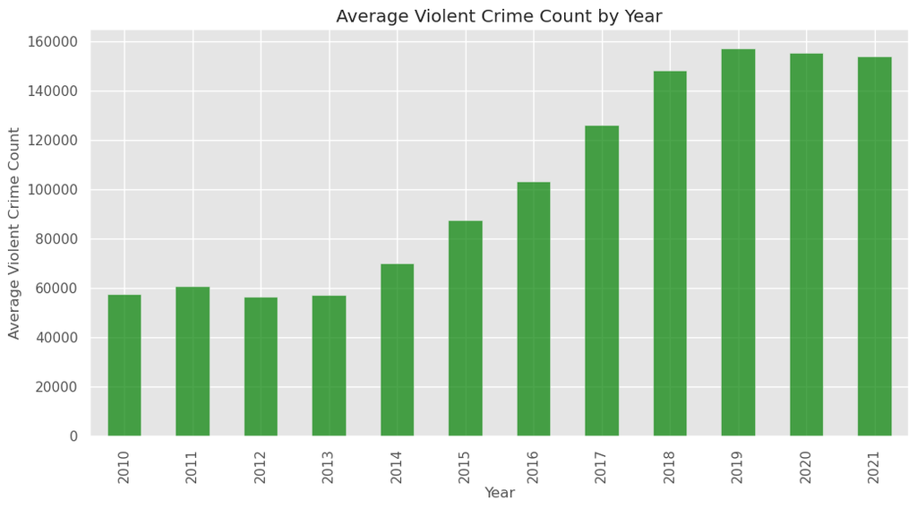

```python
# Convert 'Month' to datetime format
violentpanda2['Month'] = pd.to_datetime(violentpanda2['Month'])

# Extract the year from the 'Month' column and create a new 'Year' column
violentpanda2['Year'] = violentpanda2['Month'].dt.year

# Calculate the average crime count for each year
average_crime_per_year = violentpanda2.groupby('Year')['Total'].mean()

# Plot the bar graph
plt.figure(figsize=(12, 6))
average_crime_per_year.plot(kind='bar', color='green', alpha=0.7)
plt.xlabel('Year')
plt.ylabel('Average Violent Crime Count')
plt.title('Average Violent Crime Count by Year')
plt.show()
```

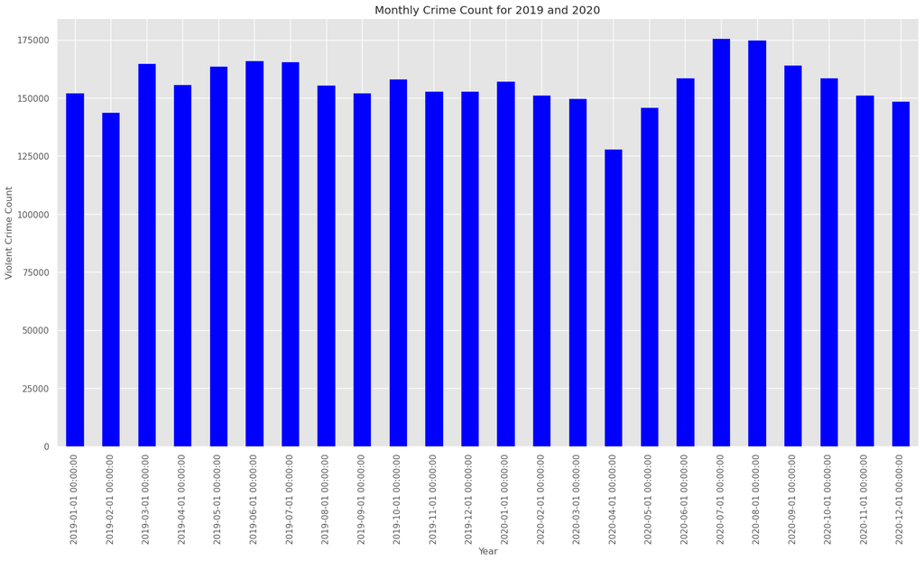

```python
crime_filt = violentpanda2[(violentpanda2['Month'].dt.year == 2019) | (violentpanda2['Month'].dt.year == 2020)]

plt.figure(figsize=(30, 10))

crime_filt.plot(kind='bar', x='Month', y='Total',
                   legend=False,
                   color='blue',
                   title='Monthly Crime Count for 2019 and 2020',
                   ylabel='Violent Crime Count',
                   xlabel='Year')

plt.show()
```

Time Series Analysis:

Time series analysis plays a role, in understanding how a specific phenomenon evolves over time. It holds importance in fields like crime research, where it enables the identification of patterns and trends related to a variable. In the realm of crime research time series analysis proves invaluable in comprehending the trajectory of crimes over time. Researchers achieve this by filtering data to focus on instances of violence and sexual offenses then utilizing a group by function to obtain the count of crimes for each month. These insights are graphically represented through time series plots with the horizontal axis denoting time and the vertical axis indicating the count of crimes. To delve deeper into analysis researchers can employ spark.sql functions to filter data based on information such as crime type and save it as a data frame, for further exploration. By trend spotting through time series analysis researchers gain insights that inform policy decisions and interventions aimed at reducing crime rates.[5]

When working with time series data it is often beneficial to break it down into parts, including level, trend, seasonality and noise. The level indicates the value, in the series while the trend shows whether the value is increasing or decreasing over time. Seasonality represents the recurring patterns in the series on a short term basis while noise refers to fluctuations in the data.

We can use a model to combine these components;

y(t) = Level + Trend + Seasonality + Noise

To separate these components and understand them better we can utilize the sm.tsa.seasonal_decompose() function. This function allows us to extract and visualize the trend seasonal variations and noise from our time series data, through graphs.[5]

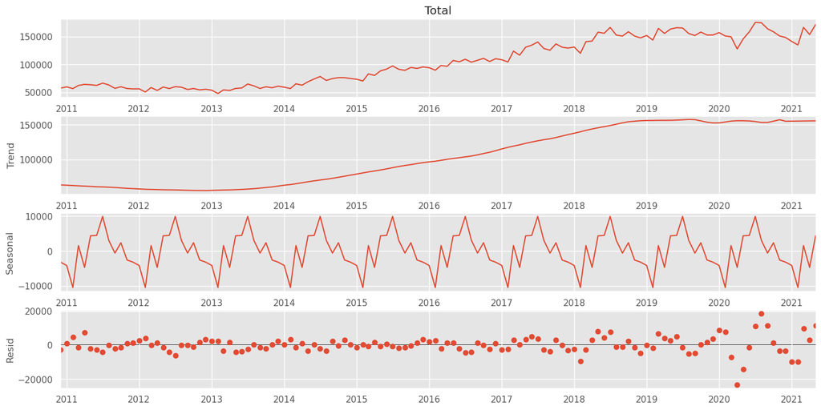

```python
decomposition = sm.tsa.seasonal_decompose(violentpanda2['Total'], model='additive',extrapolate_trend='freq')
fig = decomposition.plot()
fig.set_size_inches(14,7)
plt.show()
```

Based on the graphs plotted, it is showing that Violence and sexual offences and Violent crime has been increasing since 2013. It showed an evident rise in the sope over the years. After 2019, the numbers have remained constant and has flattened. There are seasonal variations in violent crime numbers, increasing substantially in the summer and decreasing in the winter.

In order to make predictions, about trends and patterns within data it is essential to ensure that the time series data is stationary. A time series is considered stationary when its mean and variance remain constant regardless of when it's observed. This independence, from time allows for use of time series forecasting techniques. Therefore it is imperative to analyze the time series data and eliminate any stationary components before applying forecasting methods.

As part of the study we have chosen a window of 12. We use a function called "test_stationarity" to check if an input time series is stationary. Presents them in a single plot, along with the original time series. We determine whether the time series is stationary or not by examining this representation. To calculate the mean and standard deviation we utilize the functions rolling().mean() and rolling().std(). This visual representation provides insights, into the stationarity of the time series.

As part of the study we have chosen a window of 12. We use a function called "test_stationarity" to check if an input time series is stationary. Presents them in a single plot, along with the original time series. We determine whether the time series is stationary or not by examining this representation. To calculate the mean and standard deviation we utilize the functions rolling().mean() and rolling().std(). This visual representation provides insights, into the stationarity of the time series.

```python
def test_stationaritycrimedt(timeseries, title):
    plt.clf()
    rolmean = pd.Series(timeseries).rolling(window=12).mean()
    rolstd = pd.Series(timeseries).rolling(window=12).std()

    fig, ax = plt.subplots(figsize=(16, 4))
    ax.plot(timeseries, label= title)
    ax.plot(rolmean, label='rolling mean');
    ax.plot(rolstd, label='rolling std (x10)');
    ax.legend()
    plt.show()
```

options.display.float_format = '{:.8f}'.format is used to round off float to 8 decimal points. We then call the test_stationarity function by passing the CrimeNumbers series as input.

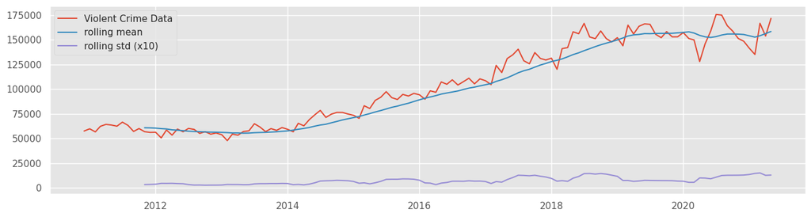

```python
pd.options.display.float_format = '{:.8f}'.format
test_stationaritycrimedt(violentpanda2['Total'],'Violent Crime Data')
```

It is worth noting that visual analysis isn't always enough to establish whether a time series is stationary or not. To complement visual analysis, we can use statistical methods such as the ADF Test (Augmented Dickey-Fuller Test) to check whether the data is stationary or not stationary. To carry out this test, we can create a function called ADF_test, which utilizes the fuller function from the statsmodels.tsa.stat tools package. This function calculates various outputs such as the test statistic, P-value, and critical values at different significance levels, which can then be used to determine whether the data is stationary or not. Based on the graphs, it seems like the series doesn't exhibit stationary behaviour.[6],[7]

```python
from statsmodels.tsa.stattools import adfuller

def ADF_test(timeseries, dataDesc):
    print(' > Is the {} stationary ?'.format(dataDesc))
    dftest = adfuller(timeseries.dropna(), autolag='AIC')
    print('Test statistic = {:.3f}'.format(dftest[0]))
    print('P-value = {:.3f}'.format(dftest[1]))
    print('Critical values :')
    for k, v in dftest[4].items():
        print('\t{}: {} - The data is {} stationary with {}% confidence'.format(k, v, 'not' if v < dftest[0] else '', 100 - int(k[:-1])))

# Assuming you have the necessary data loaded
ADF_test(violentpanda2['Total'], 'Violent Crime Data')
```

```
 > Is the Violent Crime Data stationary ?
Test statistic = -0.305
P-value = 0.925
Critical values :
	1%: -3.489589552580676 - The data is not stationary with 99% confidence
	5%: -2.887477210140433 - The data is not stationary with 95% confidence
	10%: -2.580604145195395 - The data is not stationary with 90% confidence
```

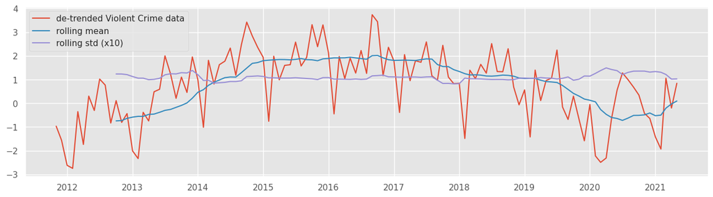

```
 > Is the de-trended Violent Crime data stationary ?
Test statistic = -1.559
P-value = 0.504
Critical values :
	1%: -3.4961490537199116 - The data is not stationary with 99% confidence
	5%: -2.8903209639580556 - The data is not stationary with 95% confidence
	10%: -2.5821223452518263 - The data is not stationary with 90% confidence
```

```python
# Detrending
y = violentpanda2['Total']
y_detrend =  (y - y.rolling(window=12).mean())/y.rolling(window=5).std()

test_stationaritycrimedt(y_detrend,'de-trended Violent Crime data')
ADF_test(y_detrend,'de-trended Violent Crime data')
```

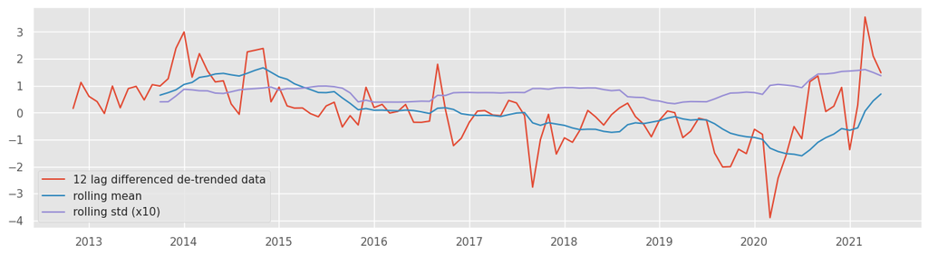

```
 > Is the 12 lag differenced de-trended data stationary ?
Test statistic = -1.907
P-value = 0.329
Critical values :
	1%: -3.505190196159122 - The data is not stationary with 99% confidence
	5%: -2.894232085048011 - The data is not stationary with 95% confidence
	10%: -2.5842101234567902 - The data is not stationary with 90% confidence
```

```python
# Detrending + Differencing

y_12lag_detrend =  y_detrend - y_detrend.shift(12)

test_stationaritycrimedt(y_12lag_detrend,'12 lag differenced de-trended data')

ADF_test(y_12lag_detrend,'12 lag differenced de-trended data')
```

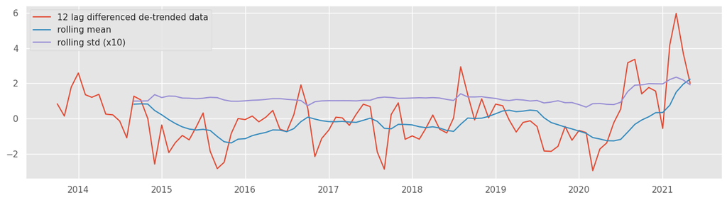

```
 > Is the 12 lag differenced de-trended data stationary ?
Test statistic = -4.312
P-value = 0.000
Critical values :
	1%: -3.5137900174243235 - The data is  stationary with 99% confidence
	5%: -2.8979433868293945 - The data is  stationary with 95% confidence
	10%: -2.5861907285474777 - The data is  stationary with 90% confidence
```

```python
# Detrending + Differencing

y_12lag_detrend1 =  y_12lag_detrend - y_12lag_detrend.shift(11)

test_stationaritycrimedt(y_12lag_detrend1,'12 lag differenced de-trended data')

ADF_test(y_12lag_detrend1,'12 lag differenced de-trended data')
```

```python
%%time
crime_pre = y_12lag_detrend.dropna()
```

```
CPU times: user 965 µs, sys: 100 µs, total: 1.07 ms
Wall time: 540 µs
```

```python
crime_pre.head()
```

```
Month
2012-11-01    0.16103033
2012-12-01    1.12527462
2013-01-01    0.60638643
2013-02-01    0.41342218
2013-03-01   -0.02868579
Name: Total, dtype: float64
```

```python
pred_train = crime_pre[:'2020-01-01'] # dataset to train
pred_test = crime_pre['2020-02-01': ] # dataset to test
y_to_value = pred_test
```

To get a list of (p, d, q) parameters and seasonal (P, D, Q) parameters, you have been exhaustively iterating all possible values of these parameters using the itertools.product() function. After obtaining all the values, you have stored them in two lists named pdq and seasonal_pdq.

```python
warnings.filterwarnings("ignore")
p = d = q = range(0, 2)
seasonal_period = 12
pdq = list(itertools.product(p, d, q))
seasonal_pdq = [(x[0], x[1], x[2],seasonal_period) for x in list(itertools.product(p, d, q))]

print('Examples of parameter combinations for Seasonal ARIMA...')
print('SARIMAX: {} x {}'.format(pdq[1], seasonal_pdq[1]))
print('SARIMAX: {} x {}'.format(pdq[1], seasonal_pdq[2]))
print('SARIMAX: {} x {}'.format(pdq[2], seasonal_pdq[3]))
print('SARIMAX: {} x {}'.format(pdq[2], seasonal_pdq[4]))
```

```
Examples of parameter combinations for Seasonal ARIMA...
SARIMAX: (0, 0, 1) x (0, 0, 1, 12)
SARIMAX: (0, 0, 1) x (0, 1, 0, 12)
SARIMAX: (0, 1, 0) x (0, 1, 1, 12)
SARIMAX: (0, 1, 0) x (1, 0, 0, 12)
```

To determine the optimal values of pdq parameters, Akaike's Information Criterion (AIC) values are used, where lower AIC values indicate better results. The grid search is performed using the sm.tsa.statespace.SARIMAX() function to obtain the AIC values for all possible combinations of pdq and seasonal pdq parameters. This helps identify the most suitable values of pdq for the given dataset.[8] To get a list of (p, d, q) parameters and seasonal (P, D, Q) parameters, you have been exhaustively iterating all possible values of these parameters using the itertools.product() function. After obtaining all the values, you have stored them in two lists named pdq and seasonal_pdq.[5]

```python
for param in pdq:
    for param_seasonal in seasonal_pdq:
        try:
            mod =\
            sm.tsa.statespace.SARIMAX(pred_train,
                                      order=param,
                                      seasonal_order=param_seasonal,
                                      enforce_invertibility=False)
            results = mod.fit()
            print('ARIMA{}x{}12 - AIC:{}'.format(param, param_seasonal, results.aic))
        except Exception as ex:
            print(ex)
            continue
```

```
ARIMA(0, 0, 0)x(0, 0, 0, 12)12 - AIC:253.65287984048888
ARIMA(0, 0, 0)x(0, 0, 1, 12)12 - AIC:253.69171075155197
ARIMA(0, 0, 0)x(0, 1, 0, 12)12 - AIC:255.7814407187891
ARIMA(0, 0, 0)x(0, 1, 1, 12)12 - AIC:236.66469200202863
ARIMA(0, 0, 0)x(1, 0, 0, 12)12 - AIC:252.77159123420597
ARIMA(0, 0, 0)x(1, 0, 1, 12)12 - AIC:253.75822274427543
ARIMA(0, 0, 0)x(1, 1, 0, 12)12 - AIC:227.28983958329857
ARIMA(0, 0, 0)x(1, 1, 1, 12)12 - AIC:229.01282117527523
ARIMA(0, 0, 1)x(0, 0, 0, 12)12 - AIC:218.89401138472988
ARIMA(0, 0, 1)x(0, 0, 1, 12)12 - AIC:220.87999220468407
ARIMA(0, 0, 1)x(0, 1, 0, 12)12 - AIC:242.47598955339913
ARIMA(0, 0, 1)x(0, 1, 1, 12)12 - AIC:216.91582284941924
ARIMA(0, 0, 1)x(1, 0, 0, 12)12 - AIC:220.8757193990088
ARIMA(0, 0, 1)x(1, 0, 1, 12)12 - AIC:222.0903449291582
ARIMA(0, 0, 1)x(1, 1, 0, 12)12 - AIC:211.56274172607903
ARIMA(0, 0, 1)x(1, 1, 1, 12)12 - AIC:212.5289705712659
ARIMA(0, 1, 0)x(0, 0, 0, 12)12 - AIC:208.918719036479
ARIMA(0, 1, 0)x(0, 0, 1, 12)12 - AIC:200.71394275759596
ARIMA(0, 1, 0)x(0, 1, 0, 12)12 - AIC:259.8393439430969
ARIMA(0, 1, 0)x(0, 1, 1, 12)12 - AIC:213.4297429239869
ARIMA(0, 1, 0)x(1, 0, 0, 12)12 - AIC:199.96430574452467
ARIMA(0, 1, 0)x(1, 0, 1, 12)12 - AIC:201.96362599338528
ARIMA(0, 1, 0)x(1, 1, 0, 12)12 - AIC:215.84865942853295
ARIMA(0, 1, 0)x(1, 1, 1, 12)12 - AIC:206.47193236479873
ARIMA(0, 1, 1)x(0, 0, 0, 12)12 - AIC:197.54628172578614
ARIMA(0, 1, 1)x(0, 0, 1, 12)12 - AIC:191.1622121457935
ARIMA(0, 1, 1)x(0, 1, 0, 12)12 - AIC:247.18271314749296
ARIMA(0, 1, 1)x(0, 1, 1, 12)12 - AIC:204.4813749764936
ARIMA(0, 1, 1)x(1, 0, 0, 12)12 - AIC:189.47125986132838
ARIMA(0, 1, 1)x(1, 0, 1, 12)12 - AIC:190.31977578149653
ARIMA(0, 1, 1)x(1, 1, 0, 12)12 - AIC:200.00714571861553
ARIMA(0, 1, 1)x(1, 1, 1, 12)12 - AIC:196.1664337916111
ARIMA(1, 0, 0)x(0, 0, 0, 12)12 - AIC:198.7933871515834
ARIMA(1, 0, 0)x(0, 0, 1, 12)12 - AIC:195.16039163298268
ARIMA(1, 0, 0)x(0, 1, 0, 12)12 - AIC:240.89569779418468
ARIMA(1, 0, 0)x(0, 1, 1, 12)12 - AIC:205.49614937279208
ARIMA(1, 0, 0)x(1, 0, 0, 12)12 - AIC:194.14712952299618
ARIMA(1, 0, 0)x(1, 0, 1, 12)12 - AIC:195.8324344379943
ARIMA(1, 0, 0)x(1, 1, 0, 12)12 - AIC:202.63819551659662
ARIMA(1, 0, 0)x(1, 1, 1, 12)12 - AIC:198.85759468555082
```

[output cut: 9 more lines]

```
ARIMA(1, 1, 0)x(0, 0, 1, 12)12 - AIC:197.1108133629303
ARIMA(1, 1, 0)x(0, 1, 0, 12)12 - AIC:258.06502749131914
ARIMA(1, 1, 0)x(0, 1, 1, 12)12 - AIC:211.28621135195908
ARIMA(1, 1, 0)x(1, 0, 0, 12)12 - AIC:195.4684043943084
ARIMA(1, 1, 0)x(1, 0, 1, 12)12 - AIC:197.13042672974007
ARIMA(1, 1, 0)x(1, 1, 0, 12)12 - AIC:208.19013505808644
ARIMA(1, 1, 0)x(1, 1, 1, 12)12 - AIC:201.93252524588138
ARIMA(1, 1, 1)x(0, 0, 0, 12)12 - AIC:193.49794918170454
ARIMA(1, 1, 1)x(0, 0, 1, 12)12 - AIC:187.72753163091357
ARIMA(1, 1, 1)x(0, 1, 0, 12)12 - AIC:242.92950084126232
ARIMA(1, 1, 1)x(0, 1, 1, 12)12 - AIC:199.77394640801035
ARIMA(1, 1, 1)x(1, 0, 0, 12)12 - AIC:186.44691382789586
ARIMA(1, 1, 1)x(1, 0, 1, 12)12 - AIC:188.02983450197672
ARIMA(1, 1, 1)x(1, 1, 0, 12)12 - AIC:200.65493957187468
ARIMA(1, 1, 1)x(1, 1, 1, 12)12 - AIC:193.899199325506
```

After analyzing the results, we can conclude that the parameters below have the lowest AIC value.

ARIMA(1, 1, 1)x(1, 0, 0, 12)12 - AIC:186.44691382789586

To obtain a predictive model, it is possible to use these values as order and seasonal order, which can be combined with data and passed to the sm.tsa.statespace.SARIMAX() function for training.

```python
order = (1, 1, 1) #Using Values from the previous step
seasonal_order = (1, 0, 0, 12)
model = sm.tsa.statespace.SARIMAX(pred_train,
                            order=order,
                            seasonal_order=seasonal_order,
                            enforce_invertibility=False)
results = model.fit()
```

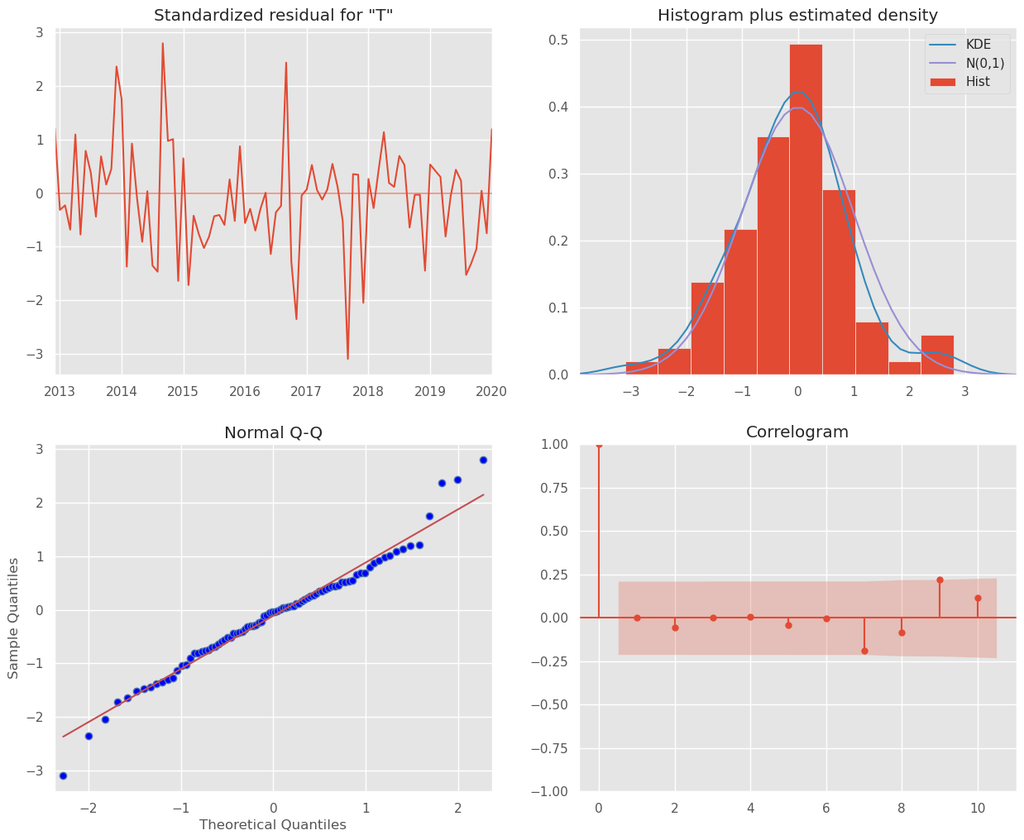

```python
results.plot_diagnostics(figsize=(15, 12))
plt.show()
```

From the output graphs, we can see that the residues are stationary with the same mean and variance and without trend, the Q-Q plot is roughly straight, Correlogram points are within the boundary, and the histogram is normal.

To predict future results, we use the get_forecast() function with step=12. This predicts values for the next 12 months. We use conf_int() to obtain the confidence interval with 95% certainty.

```python
pred_uc = results.get_forecast(steps=12)
pred_ci = pred_uc.conf_int()
```

```python
# Produce the forcasted tables
pm = pred_uc.predicted_mean.reset_index()
pm.columns = ['Date','Predicted_Mean']
pci = pred_ci.reset_index()
pci.columns = ['Date','Lower Bound','Upper Bound']
final_table = pm.join(pci.set_index('Date'), on='Date')
```

```python
final_table.head(12)
```

|  | Date | Predicted_Mean | Lower Bound | Upper Bound |
| --- | --- | --- | --- | --- |
| 0 | 2020-02-01 | -0.97153945 | -2.29470694 | 0.35162804 |
| 1 | 2020-03-01 | -1.04556749 | -2.55707329 | 0.46593831 |
| 2 | 2020-04-01 | -0.78046950 | -2.37400775 | 0.81306874 |
| 3 | 2020-05-01 | -0.87138904 | -2.51896635 | 0.77618826 |
| 4 | 2020-06-01 | -1.03291942 | -2.72502598 | 0.65918714 |
| 5 | 2020-07-01 | -1.01281785 | -2.74556884 | 0.71993315 |
| 6 | 2020-08-01 | -0.61681106 | -2.38827438 | 1.15465225 |
| 7 | 2020-09-01 | -0.44853748 | -2.25751467 | 1.36043972 |
| 8 | 2020-10-01 | -0.45271863 | -2.29830942 | 1.39287216 |
| 9 | 2020-11-01 | -0.66321973 | -2.54466019 | 1.21822074 |
| 10 | 2020-12-01 | -0.60959836 | -2.52619877 | 1.30700205 |
| 11 | 2021-01-01 | -0.90332578 | -2.85444542 | 1.04779386 |

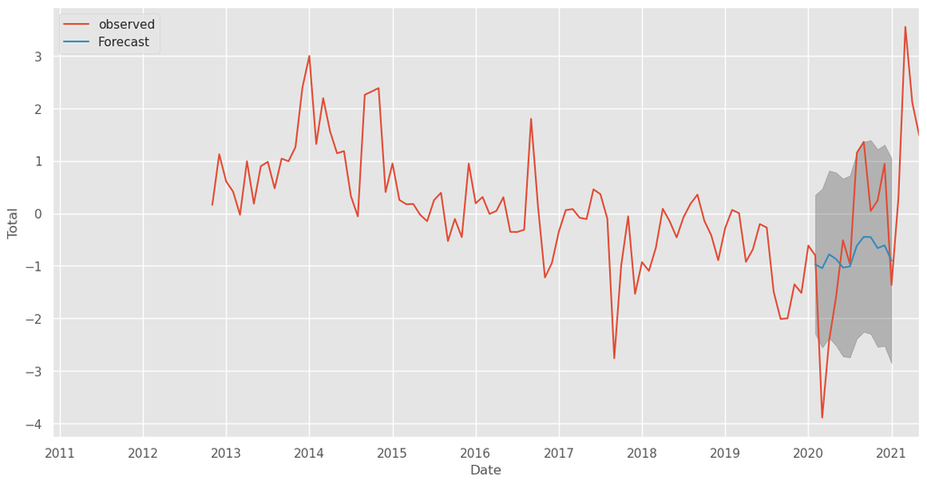

```python
ax = y_12lag_detrend.plot(label='observed', figsize=(14, 7))
#     print(pred_uc.predicted_mean)
pred_uc.predicted_mean.plot(ax=ax, label='Forecast')
ax.fill_between(pred_ci.index,
                pred_ci.iloc[:, 0],
                pred_ci.iloc[:, 1], color='k', alpha=.25)
ax.set_xlabel('Date')
#ax.set_ylabel('Total')
ax.set_ylabel(y.name)

plt.legend()
plt.show()
```

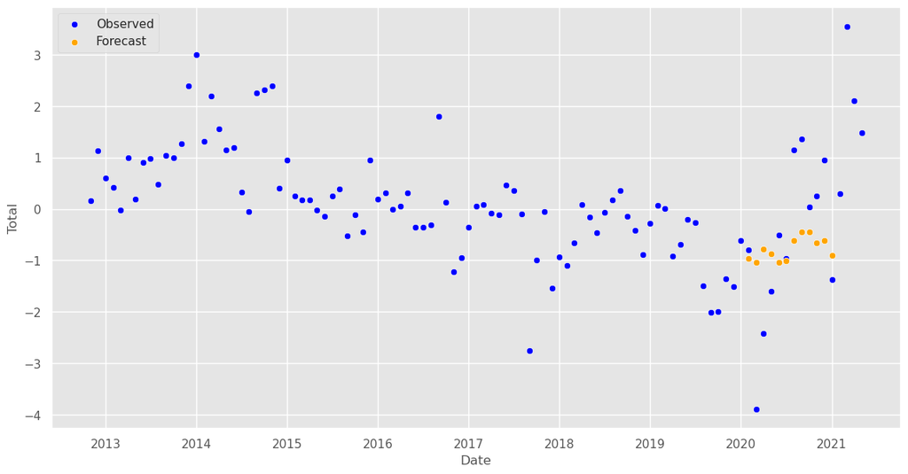

```python
import seaborn as sns
import matplotlib.pyplot as plt

# Assuming pred_uc, pred_ci, and y_12lag_detrend are defined

# Create a new figure with Seaborn
plt.figure(figsize=(14, 7))

# Plot the observed data as a scatter plot
sns.scatterplot(x=y_12lag_detrend.index, y=y_12lag_detrend, label='Observed', color='blue')

# Plot the forecasted mean as points
sns.scatterplot(x=pred_uc.predicted_mean.index, y=pred_uc.predicted_mean, label='Forecast', color='orange')

# Set labels
plt.xlabel('Date')
plt.ylabel(y_12lag_detrend.name)

# Show legend
plt.legend()

# Show the plot
plt.show()
```

Based on the graphs that were plotted it is evident that there was a rise, in the crime rate between April and August 2020. This trend was quite worrisome. Caused both law enforcement agencies and citizens to be alarmed. However everyone felt relieved when the crime rate suddenly decreased from August to December 2020. It was a change that brought hope indicating that things were moving in the direction.[9]

The sudden drop in crime rate can be attributed to factors, including law enforcement measures, community policing efforts and increased awareness among citizens. It is also possible that the COVID 19 pandemic played a role in reducing activities. With people staying indoors and fewer individuals on the streets criminals may have had opportunities to commit offenses.

Unfortunately this relief didn't last long as the crime rate started increasing in months. There are reasons for this rise, such as the easing of lockdown restrictions economic uncertainty and social unrest. It is crucial to analyze the data regarding this increase, in crime rate and take measures to prevent it.

```python
merged_df = pd.merge(final_table, crime_pre, left_on='Date', right_on='Month', how='inner')

# Print the merged DataFrame
print(merged_df)
```

```
         Date  Predicted_Mean  Lower Bound  Upper Bound       Total
0  2020-02-01     -0.97153945  -2.29470694   0.35162804 -0.80080564
1  2020-03-01     -1.04556749  -2.55707329   0.46593831 -3.89093974
2  2020-04-01     -0.78046950  -2.37400775   0.81306874 -2.42343108
3  2020-05-01     -0.87138904  -2.51896635   0.77618826 -1.59515432
4  2020-06-01     -1.03291942  -2.72502598   0.65918714 -0.51272661
5  2020-07-01     -1.01281785  -2.74556884   0.71993315 -0.96381359
6  2020-08-01     -0.61681106  -2.38827438   1.15465225  1.15224298
7  2020-09-01     -0.44853748  -2.25751467   1.36043972  1.36201765
8  2020-10-01     -0.45271863  -2.29830942   1.39287216  0.04432713
9  2020-11-01     -0.66321973  -2.54466019   1.21822074  0.24323733
10 2020-12-01     -0.60959836  -2.52619877   1.30700205  0.94220031
11 2021-01-01     -0.90332578  -2.85444542   1.04779386 -1.36911494
```

```python
y_to_value.head(9)
```

```
Month
2020-02-01   -0.80080564
2020-03-01   -3.89093974
2020-04-01   -2.42343108
2020-05-01   -1.59515432
2020-06-01   -0.51272661
2020-07-01   -0.96381359
2020-08-01    1.15224298
2020-09-01    1.36201765
2020-10-01    0.04432713
Name: Total, dtype: float64
```

```python
final_table.head(12)
```

|  | Date | Predicted_Mean | Lower Bound | Upper Bound |
| --- | --- | --- | --- | --- |
| 0 | 2020-02-01 | -0.97153945 | -2.29470694 | 0.35162804 |
| 1 | 2020-03-01 | -1.04556749 | -2.55707329 | 0.46593831 |
| 2 | 2020-04-01 | -0.78046950 | -2.37400775 | 0.81306874 |
| 3 | 2020-05-01 | -0.87138904 | -2.51896635 | 0.77618826 |
| 4 | 2020-06-01 | -1.03291942 | -2.72502598 | 0.65918714 |
| 5 | 2020-07-01 | -1.01281785 | -2.74556884 | 0.71993315 |
| 6 | 2020-08-01 | -0.61681106 | -2.38827438 | 1.15465225 |
| 7 | 2020-09-01 | -0.44853748 | -2.25751467 | 1.36043972 |
| 8 | 2020-10-01 | -0.45271863 | -2.29830942 | 1.39287216 |
| 9 | 2020-11-01 | -0.66321973 | -2.54466019 | 1.21822074 |
| 10 | 2020-12-01 | -0.60959836 | -2.52619877 | 1.30700205 |
| 11 | 2021-01-01 | -0.90332578 | -2.85444542 | 1.04779386 |

```python
%%time

Lcsviolcr_count  = spark.sql("SELECT LSOA_name, COUNT(*) AS cnt FROM hkdata GROUP BY LSOA_name ORDER BY cnt DESC")
Lcsviolcr_count.show()
```

```
+--------------------+-------+
|           LSOA_name|    cnt|
+--------------------+-------+
|                null|2528265|
|    Westminster 013E|  78858|
|    Westminster 018A|  72772|
|          Leeds 111B|  71368|
| City of London 001F|  61348|
|    Westminster 013B|  58994|
|Newcastle upon Ty...|  53660|
|    Westminster 018C|  52905|
|     Manchester 054C|  52478|
|     Birmingham 138A|  52476|
|      Leicester 041A|  51488|
|          Derby 013F|  51452|
|     Manchester 055B|  50951|
|Brighton and Hove...|  46143|
|        Cardiff 032F|  44752|
|        Bristol 032B|  42590|
|Newcastle upon Ty...|  39005|
|     Hillingdon 031A|  38258|
|      Liverpool 061C|  37758|
|      Liverpool 060C|  37188|
+--------------------+-------+
only showing top 20 rows

CPU times: user 11.3 ms, sys: 6.1 ms, total: 17.4 ms
Wall time: 2min 17s
```

```python
Lcsviol_crimes = spark.sql("""
    SELECT Month, COUNT(`Crime_type`) AS Total
    FROM hkdata
    WHERE LSOA_name LIKE '%Leicester %'
        AND `Crime_type` IN ('Violent crime', 'Violence and sexual offences')
        AND Month >= '2019-12-01'
    GROUP BY Month
    ORDER BY Month
""")
```

```python
%%time
Lcsviol_crimespd = Lcsviol_crimes.toPandas()
```

```
CPU times: user 19.9 ms, sys: 2.27 ms, total: 22.2 ms
Wall time: 2min 3s
```

```python
Lcsviol_crimespd
```

|  | Month | Total |
| --- | --- | --- |
| 0 | 2020-01 | 1266 |
| 1 | 2020-02 | 1173 |
| 2 | 2020-03 | 1317 |
| 3 | 2020-04 | 1136 |
| 4 | 2020-05 | 1316 |
| 5 | 2020-06 | 1386 |
| 6 | 2020-07 | 1489 |
| 7 | 2020-08 | 1602 |
| 8 | 2020-09 | 1528 |
| 9 | 2020-10 | 1560 |
| 10 | 2020-11 | 1463 |
| 11 | 2020-12 | 1401 |
| 12 | 2021-01 | 1369 |
| 13 | 2021-02 | 1323 |
| 14 | 2021-03 | 1605 |
| 15 | 2021-04 | 1531 |
| 16 | 2021-05 | 1609 |

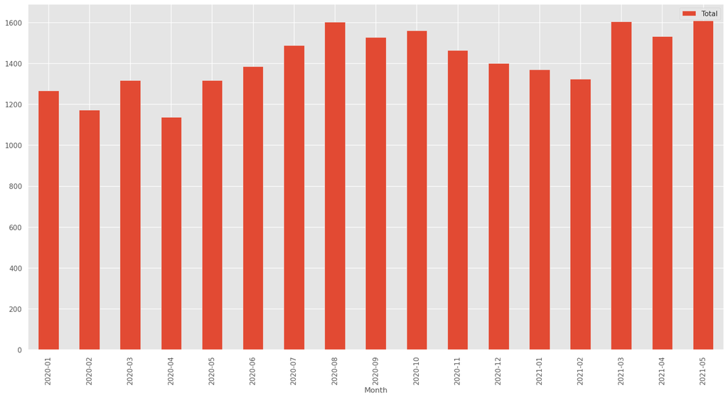

```
CPU times: user 253 ms, sys: 8.55 ms, total: 261 ms
Wall time: 259 ms
```

```python
%%time
Lcsviol_crimespd.plot.bar(x='Month', y='Total')

plt.show()
```

```python
Lcsviol_crimespd.Month = Lcsviol_crimespd.Month.astype('datetime64[ns]')
Lcsviol_crimespd = Lcsviol_crimespd.set_index(pd.to_datetime(Lcsviol_crimespd.Month))
```

```python
Lcsviol_crimespd.index
```

```
DatetimeIndex(['2020-01-01', '2020-02-01', '2020-03-01', '2020-04-01',
               '2020-05-01', '2020-06-01', '2020-07-01', '2020-08-01',
               '2020-09-01', '2020-10-01', '2020-11-01', '2020-12-01',
               '2021-01-01', '2021-02-01', '2021-03-01', '2021-04-01',
               '2021-05-01'],
              dtype='datetime64[ns]', name='Month', freq=None)
```

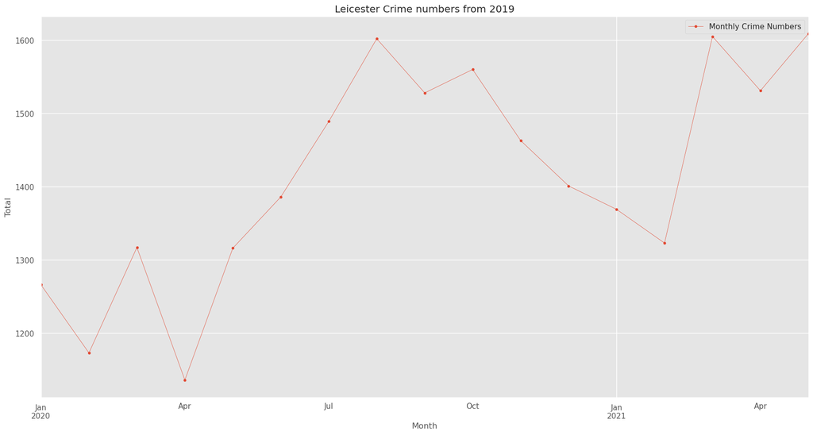

```python
Lcsviol_crimespd['Month'] = Lcsviol_crimespd['Month'].astype('datetime64[ns]')
Lcsviol_crimespd = Lcsviol_crimespd.set_index(pd.to_datetime(Lcsviol_crimespd['Month']))

plt.figure(figsize=(20, 6))

Lcsviol_crimespd.plot(y='Total', x='Month', marker='.', linestyle='-', linewidth=0.5,
                      subplots=False, label='Monthly Crime Numbers',
                      title='Leicester Crime numbers from 2019')

plt.ylabel('Total')

plt.show()
```

Conclusion:

This study underscores the importance of acknowledging fluctuations when devising strategies to combat crime rates during pandemics. It further emphasizes the necessity, for monitoring of crime rates to grasp their dynamics fully and develop control measures.

Refrences

[1]Y. Sun, Y. Huang, K. Yuan, T. O. Chan, and Y. Wang, “Spatial Patterns of COVID-19 Incidence in Relation to Crime Rate Across London,” ISPRS International Journal of Geo-Information, vol. 10, no. 2, p. 53, Jan. 2021, doi: https://doi.org/10.3390/ijgi10020053.

[2]D. Flynn et al., “COVID-19 pandemic in the United Kingdom,” Health Policy and Technology, vol. 9, no. 4, pp. 673–691, Aug. 2020, doi: https://doi.org/10.1016/j.hlpt.2020.08.003.

[3]T. Kirchmaier and C. Villa-Llera, “COVID-19 and Changing Crime Trends in England and Wales,” papers.ssrn.com, Dec. 17, 2020. https://papers.ssrn.com/sol3/papers.cfm?abstract_id=3700329

[4]K. C. Neanidis and Maria Paola Rana, “Crime in the era of COVID‐19: Evidence from England,” Journal of Regional Science, Jun. 2023, doi: https://doi.org/10.1111/jors.12656.

[5]G. Peter. Zhang, “Time series forecasting using a hybrid ARIMA and neural network model,” Neurocomputing, vol. 50, pp. 159–175, Jan. 2003, doi: https://doi.org/10.1016/s0925-2312(01)00702-0.

[6]T. C. Mills, “Dealing with Nonstationarity: Detrending, Smoothing and Differencing,” Palgrave Macmillan UK eBooks, pp. 261–288, Jan. 2011, doi: https://doi.org/10.1057/9780230305021_10.

[7]D. Kwiatkowski, P. C. B. Phillips, P. Schmidt, and Y. Shin, “Testing the null hypothesis of stationarity against the alternative of a unit root,” Journal of Econometrics, vol. 54, no. 1–3, pp. 159–178, Oct. 1992, doi: https://doi.org/10.1016/0304-4076(92)90104-y.

[8]Tshepo Chris Nokeri, “Forecasting Using ARIMA, SARIMA, and the Additive Model,” Apress eBooks, pp. 21–50, Jan. 2021, doi: https://doi.org/10.1007/978-1-4842-7110-0_2.

[9]D. A. Keim, M. C. Hao, U. Dayal, H. Janetzko, and P. Bak, “Generalized Scatter Plots,” Information Visualization, vol. 9, no. 4, pp. 301–311, Dec. 2009, doi: https://doi.org/10.1057/ivs.2009.34.

[10]M. Lemon, M. G. Pollitt, and S. Steer, “Local energy policy and managing low carbon transition: The case of Leicester, UK,” Energy Strategy Reviews, vol. 6, pp. 57–63, Jan. 2015, doi: https://doi.org/10.1016/j.esr.2015.02.001.